# SASProject1_Mohammadhossein_Toutiaee

#### Program: SAS Programming

#### Author: Mohammadhossein Toutiaee (hossein@uga.edu)

#### Written: 05/03/17

#### Question 1:

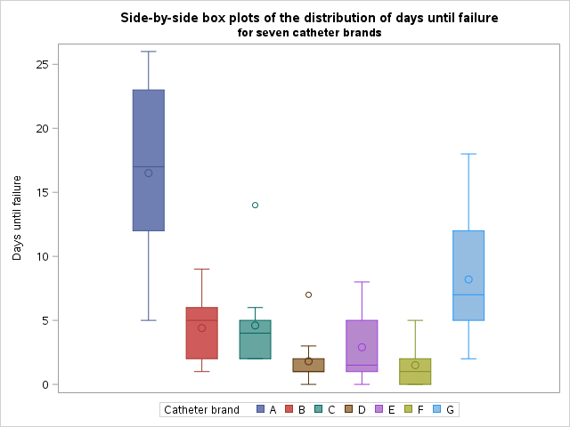

```sas
libname SASdata "/folders/myshortcuts/myFolders/Data Files";
filename assaydat "/folders/myshortcuts/myFolders/Data Files/Assay.dat";

ods html file="/folders/myshortcuts/myFolders/SAS code/Project1.html"
         gpath="/folders/myshortcuts/myFolders/SASgraphs";

ODS GRAPHICS / RESET IMAGENAME='Project1' outputfmt=PNG ;

data assay;
  infile assaydat firstobs=2;
  input cathname $ rep days;
  label days="Days until failure" cathname="Catheter brand";
run;
* Part a: Produce side-by-side box plots of days until failure by catheter brand;

proc sort data=assay;
  by cathname rep;
run;
title 'Side-by-side box plots of the distribution of days until failure';
title2 'for seven catheter brands';
proc sgplot data=assay;
  vbox days/group=cathname;
  label days="Days until failure" cathname="Catheter brand";
run;
```

##### 1-a)

Side-by-side box plots of days until failure are given in Figure 1. This graph shows that the distribution of days until failure differs substantially from one catheter brand to another. In particular, Brands A and G have larger means and larger variances than the other brands. Brands D and F seem to have both the smallest mean and the smallest variance. In general, there is a tendency for catheter brands with large means to also have large variances. This phenomenon, variance that increases with the mean, is a common form of heteroscedasticity.

```sas
* Part b: Fit one-way anova model, test equality of population means, and
          test homogeneity of variance.;

ods graphics off; ods trace on;
proc glm data=assay;
title 'One-way anova in PROC GLM analyzing days until failure';
title2 'for seven catheter brands';
  class cathname;
  model days=cathname/ss3; * Type 1 and 3 F tests are same in one-way model so
                             here the ss3 option asks for just the Type 3 tests,
                             which suppresses the Type 1 tests and eliminates
                             redundant output;
  means cathname/hovtest=bf;
  means cathname/hovtest=levene(type=abs);
  means cathname/hovtest=levene(type=square);
  ods exclude means#2 means#3; *This suppresses 2 of the three identical tables of
                                sample means that were generated by having three
                                MEANS statements in this code;
run;
```

One-way anova in PROC GLM analyzing days until failure

for seven catheter brands

The GLM Procedure

| Class Level Information Class | Class Level Information Levels | Class Level Information Values |
| --- | --- | --- |
| cathname | 7 | A B C D E F G |

| Number of Observations Read | 70 |
| --- | --- |
| Number of Observations Used | 70 |

One-way anova in PROC GLM analyzing days until failure

for seven catheter brands

The GLM Procedure

Dependent Variable: days Days until failure

| Source | DF | Sum of Squares | Mean Square | F Value | Pr > F |
| --- | --- | --- | --- | --- | --- |
| Model | 6 | 1664.800000 | 277.466667 | 18.14 | <.0001 |
| Error | 63 | 963.900000 | 15.300000 |  |  |
| Corrected Total | 69 | 2628.700000 |  |  |  |

| R-Square | Coeff Var | Root MSE | days Mean |
| --- | --- | --- | --- |
| 0.633317 | 68.62318 | 3.911521 | 5.700000 |

| Source | DF | Type III SS | Mean Square | F Value | Pr > F |
| --- | --- | --- | --- | --- | --- |
| cathname | 6 | 1664.800000 | 277.466667 | 18.14 | <.0001 |

One-way anova in PROC GLM analyzing days until failure

for seven catheter brands

The GLM Procedure

| Brown and Forsythe's Test for Homogeneity of days Variance ANOVA of Absolute Deviations from Group Medians Source | Brown and Forsythe's Test for Homogeneity of days Variance ANOVA of Absolute Deviations from Group Medians DF | Brown and Forsythe's Test for Homogeneity of days Variance ANOVA of Absolute Deviations from Group Medians Sum of Squares | Brown and Forsythe's Test for Homogeneity of days Variance ANOVA of Absolute Deviations from Group Medians Mean Square | Brown and Forsythe's Test for Homogeneity of days Variance ANOVA of Absolute Deviations from Group Medians F Value | Brown and Forsythe's Test for Homogeneity of days Variance ANOVA of Absolute Deviations from Group Medians Pr > F |
| --- | --- | --- | --- | --- | --- |
| cathname | 6 | 127.1 | 21.1905 | 2.89 | 0.0149 |
| Error | 63 | 461.8 | 7.3302 |  |  |

One-way anova in PROC GLM analyzing days until failure

for seven catheter brands

The GLM Procedure

| Level of cathname | N | days Mean | days Std Dev |
| --- | --- | --- | --- |
| A | 10 | 16.5000000 | 6.94822120 |
| B | 10 | 4.4000000 | 2.41292814 |
| C | 10 | 4.6000000 | 3.65756446 |
| D | 10 | 1.8000000 | 1.98885785 |
| E | 10 | 2.9000000 | 2.84604989 |
| F | 10 | 1.5000000 | 1.58113883 |
| G | 10 | 8.2000000 | 5.00666223 |

One-way anova in PROC GLM analyzing days until failure

for seven catheter brands

The GLM Procedure

| Levene's Test for Homogeneity of days Variance ANOVA of Absolute Deviations from Group Means Source | Levene's Test for Homogeneity of days Variance ANOVA of Absolute Deviations from Group Means DF | Levene's Test for Homogeneity of days Variance ANOVA of Absolute Deviations from Group Means Sum of Squares | Levene's Test for Homogeneity of days Variance ANOVA of Absolute Deviations from Group Means Mean Square | Levene's Test for Homogeneity of days Variance ANOVA of Absolute Deviations from Group Means F Value | Levene's Test for Homogeneity of days Variance ANOVA of Absolute Deviations from Group Means Pr > F |
| --- | --- | --- | --- | --- | --- |
| cathname | 6 | 124.1 | 20.6819 | 3.64 | 0.0037 |
| Error | 63 | 358.3 | 5.6865 |  |  |

One-way anova in PROC GLM analyzing days until failure

for seven catheter brands

The GLM Procedure

| Levene's Test for Homogeneity of days Variance ANOVA of Squared Deviations from Group Means Source | Levene's Test for Homogeneity of days Variance ANOVA of Squared Deviations from Group Means DF | Levene's Test for Homogeneity of days Variance ANOVA of Squared Deviations from Group Means Sum of Squares | Levene's Test for Homogeneity of days Variance ANOVA of Squared Deviations from Group Means Mean Square | Levene's Test for Homogeneity of days Variance ANOVA of Squared Deviations from Group Means F Value | Levene's Test for Homogeneity of days Variance ANOVA of Squared Deviations from Group Means Pr > F |
| --- | --- | --- | --- | --- | --- |
| cathname | 6 | 13128.7 | 2188.1 | 3.79 | 0.0027 |
| Error | 63 | 36344.5 | 576.9 |  |  |